# kalman_filter

Qi

2023-06-04

#Function List $\bullet$ `kalmanSimulate` $\bullet$ `kalman`: $\bullet$ `kf.gp`: $\bullet$ `kf.loglikelihood` $\bullet$ `optim_parm`

```r
library(microbenchmark)
library(dplyr)
library(pander)
library(data.table)
```

# Simulated Data

## Simulation of state-space model.

The following code simulate the state space model of the form
$$X_t = \phi X_{t-1} + V$$
$$Y_t = X_t + W$$
where $W\sim \mathcal{N}(0,\sigma_w^2)$ and $V\sim \mathcal{N}(0,\sigma_v^2)$.

```r
set.seed(100)
#all Sigma here are variance namely $\sigma^2$, and lower case sigma means standard deviation.

kalmanSimulate <- function(T=100,m0=0,Sigma0=1,phi=1,Sigmav=0.02,Sigmaw=0.2){
  x <- rep(NA,T)
  y<- rep(NA,T)

  #create the hidden states X_t
  x[1]<-rnorm(1,mean=m0,sd=sqrt(Sigma0))
  for (i in 2:T){
    x[i] <- phi*x[i-1] + rnorm(1,mean=0,sd=sqrt(Sigmav))
  }

  #create the observed states Y_t
  for (i in 1:T){
    y[i] <- x[i] + rnorm(1,mean=0,sd=sqrt(Sigmaw))
  }
  return (list("x"=x,"y"=y))
}
```

We now simulate a dataset with length 100.

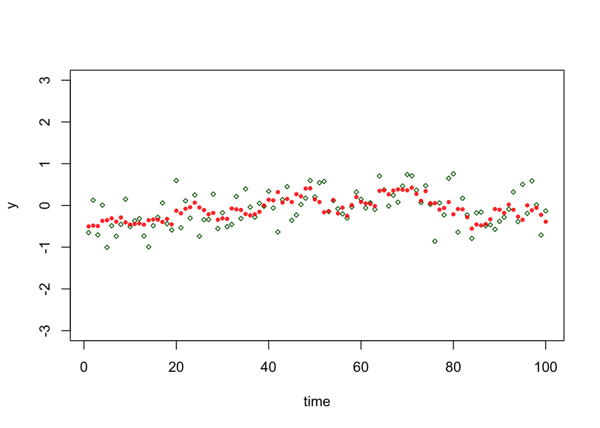

```r
simulation <- kalmanSimulate()
y <- simulation$y
originalX <- simulation$x
time <- c(1:length(y))
plot(time,y,cex=0.5,col='darkgreen',pch=5,ylim=c(-3,3))
points(time,originalX,cex=0.5,col='red',pch=10)
```

The red dots are hidden states and the green dots are the observed values which involves some independent noise.

## Kalman Filter

We will first write a Kalman filter for general state-space model, then embed that function to our specific case with $\phi = \exp(-\frac{1}{\gamma})$ and $\sigma_v^2 = 1-\exp(-\frac{2}{\gamma})$.

The `Kalman` function takes inputs $\phi$, $\sigma_v^2$, $\sigma_w^2$, $m_0$ and $\sigma_0^2$, it returns a the predicted mean, predicted variance, updated mean, updated variance, smoothing mean and smoothing variance.

```r
kalman <- function(y,phi,Sigmav,Sigmaw,m0,Sigma0){

  T <- length(y)

  #initialization
  mu.p <- rep(NA,T)
  Sigma.p <- rep(NA,T)
  mu.f <- rep(NA,T)
  Sigma.f <- rep(NA,T)
  mu.s <- rep(NA,T)
  Sigma.s <- rep(NA,T)


  #forward recursion time1
  mu.p[1] <- m0
  Sigma.p[1] <- Sigma0
  mu.f[1] <- m0 + (y[1]-m0)*(Sigma0/(Sigma0+Sigmaw))
  Sigma.f[1] <- Sigma0-(Sigma0^2/(Sigma0+Sigmaw))

  #forward recursion time 2:T
  for (t in 2:T){

    #prediction
    mu.p[t] <- phi*mu.f[t-1]
    Sigma.p[t] <- phi^2 * Sigma.f[t-1] + Sigmaw

    #update
    deno <- Sigmaw + Sigma.p[t]
    mu.f[t] <- Sigmaw*mu.p[t]/deno + Sigma.p[t]*y[t]/deno
    Sigma.f[t] <- Sigmaw*Sigma.p[t]/deno
  }

  #backword recursion
  mu.s[T] <- mu.f[T]
  Sigma.s[T] <- Sigma.f[T]
  for (t in (T-1):1){
    J <- phi*Sigma.f[t]/Sigma.p[t+1]
    mu.s[t] <- mu.f[t] + J*(mu.s[t+1]-mu.p[t+1])
    Sigma.s[t] <- Sigma.f[t] + J^2*(Sigma.s[t+1]-Sigma.p[t+1])
  }
  return (list(mu.f=mu.f,Sigma.f=Sigma.f,mu.p=mu.p,Sigma.p=Sigma.p,mu.s=mu.s,Sigma.s=Sigma.s))
}
```

We first do some experiments to see if the Kalman Filter Algorithm itself makes sense:

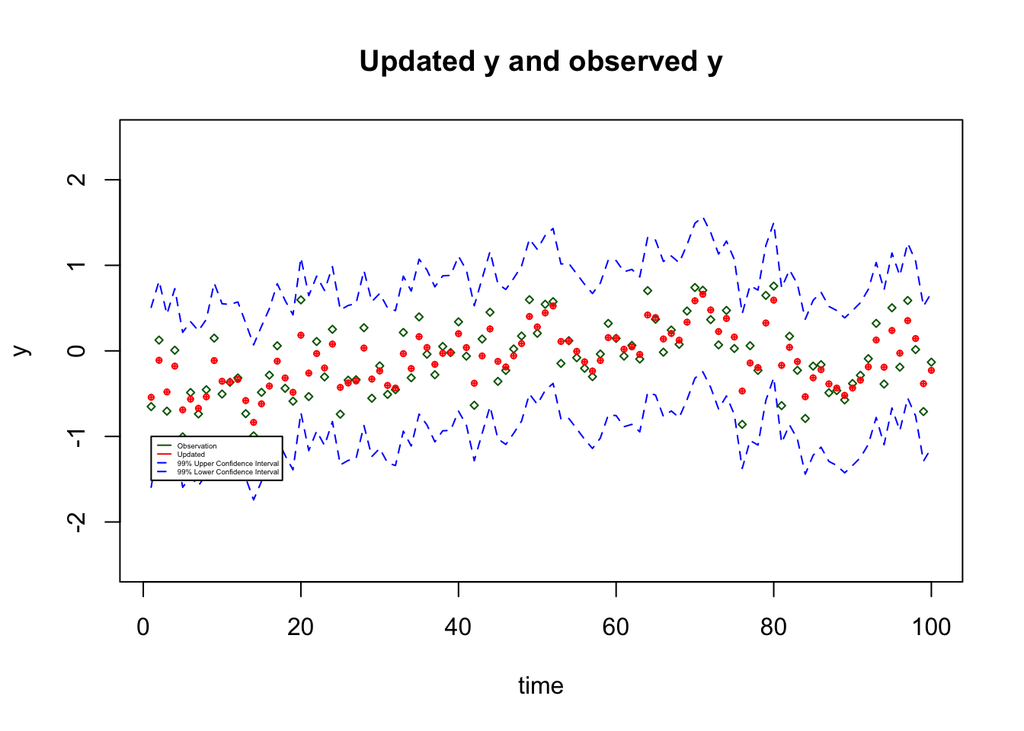

```r
results.KF <- kalman(y,phi=1,Sigmav=0.02,Sigmaw=0.2,m0=0,Sigma0=1)
mu.f <- results.KF$mu.f
Sigma.f <- results.KF$Sigma.f

se.f <- sqrt(Sigma.f)

alpha=0.01
cv99 = qnorm(1-alpha/2)
CIupper.f <- mu.f + cv99*se.f
CIlower.f <- mu.f - cv99*se.f

plot(time,y,cex=0.5,col='darkgreen',pch=5,ylim=c(-2.5,2.5),main='Updated y and observed y')
points(time,mu.f,cex=0.5,col='red',pch=10)
points(time,CIupper.f,col='blue',type ='l',lty=2,lwd=1)
points(time,CIlower.f,col='blue',type ='l',lty=2,lwd=1)
legend(1,-1,legend= c('Observation','Updated','99% Upper Confidence Interval','99% Lower Confidence Interval'), col=c('darkgreen','red','blue','blue'),lty=c(1,1,2,2),cex=.3)
```

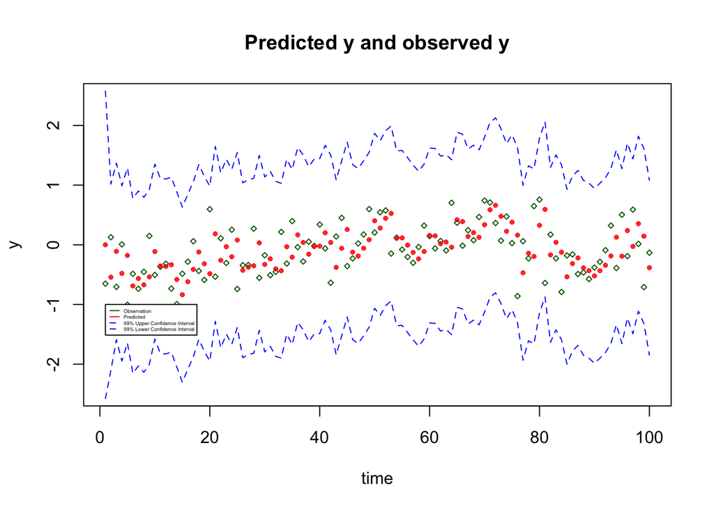

```r
mu.p <- results.KF$mu.p
Sigma.p <- results.KF$Sigma.p

se.p <- sqrt(Sigma.p)

alpha=0.01
cv99 = qnorm(1-alpha/2)
CIupper.p <- mu.p + cv99*se.p
CIlower.p <- mu.p - cv99*se.p

plot(time,y,cex=0.5,col='darkgreen',pch=5,ylim=c(-2.5,2.5),main='Predicted y and observed y')
points(time,mu.p,cex=0.5,col='red',pch=10)
points(time,CIupper.p,col='blue',type ='l',lty=2,lwd=1)
points(time,CIlower.p,col='blue',type ='l',lty=2,lwd=1)
legend(1,-1,legend= c('Observation','Predicted','99% Upper Confidence Interval','99% Lower Confidence Interval'), col=c('darkgreen','red','blue','blue'),lty=c(1,1,2,2),cex=.3)
```

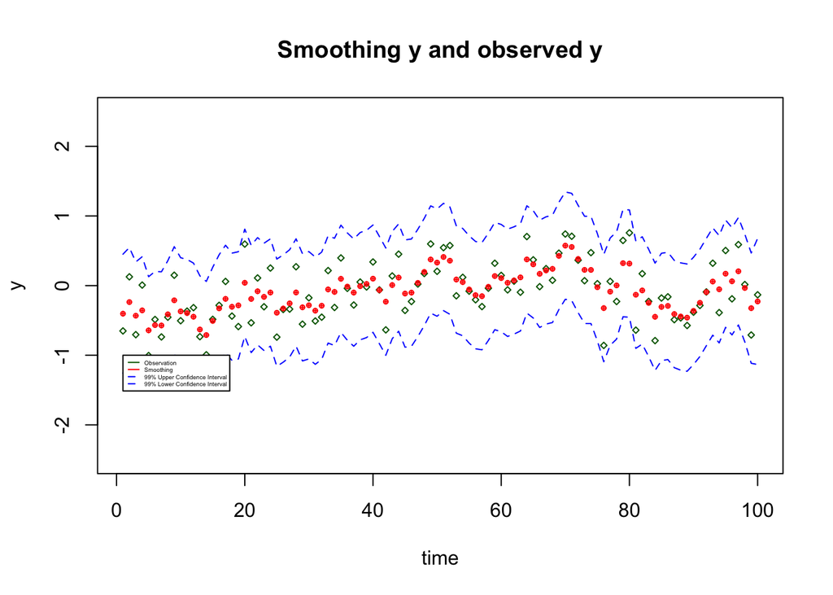

```r
mu.s <- results.KF$mu.s
Sigma.s <- results.KF$Sigma.s

se.s <- sqrt(Sigma.s)

alpha=0.01
cv99 = qnorm(1-alpha/2)
CIupper.s <- mu.s + cv99*se.s
CIlower.s <- mu.s - cv99*se.s

plot(time,y,cex=0.5,col='darkgreen',pch=5,ylim=c(-2.5,2.5),main='Smoothing y and observed y')
points(time,mu.s,cex=0.5,col='red',pch=10)
points(time,CIupper.s,col='blue',type ='l',lty=2,lwd=1)
points(time,CIlower.s,col='blue',type ='l',lty=2,lwd=1)
legend(1,-1,legend= c('Observation','Smoothing','99% Upper Confidence Interval','99% Lower Confidence Interval'), col=c('darkgreen','red','blue','blue'),lty=c(1,1,2,2),cex=.3)
```

The result makes sense, that smoothing distribution is indeed ‘smoother’ than the predicted values and updated values. Also we notice that the confidence interval for predictions are rather wide. All the observed values are contained in the confidence interval.

```r
kf.gp <- function(y,gamma,Sigmaw,m0=0,Sigma0=1){
  T=length(y)
  #update Sigmav and phi
  phi <- exp(-1/gamma)
  Sigmav <- 1-exp(-2/gamma)
  result <- kalman(y,phi=phi,Sigmav=Sigmav,Sigmaw=Sigmaw,m0=m0,Sigma0=Sigma0)

  return (list(mu.p=result$mu.p, Sigma.p=result$Sigma.p,
               mu.f=result$mu.f, Sigma.f=result$Sigma.f,
               mu.s=result$mu.s, Sigma.s=result$Sigma.s))

}

kf.loglikelihood1 <- function(y,mu.p,Sigma.p,Sigmaw,m0=0,Sigma0=1){
  T <- length(y)
  likelihood <- rep(NA,T)

  #at time 1
  likelihood[1] <- log(dnorm(y[1],mean=m0,sd = sqrt(Sigma0 + Sigmaw)))

  #time 2:T
  for (t in 2:T){
    likelihood[t] <- log(dnorm(y[t],mean=mu.p[t],sd=sqrt(Sigmaw+Sigma.p[t])))
  }
  return (sum(likelihood))
}
```

There are two functions here: $\bullet$ `kf.gp` simply applies the Kalman Filter on observed $y$, with $\sigma_v^2$ and $\phi$ as functions of hyper parameter $\gamma$, computing the predictive, updated and smoothing distributions. $\bullet$ `kf.loglikelihood` computes the loglikelihood of the observed $y$ in a recursive regression by noting
$$\log(p(y_{1:T}) = p(y_1) + \sum_{t=2}^T
p(y_t|y_{1:t-1})$$
and
$$p(y_t|y_{1:t-1}) =
\mathcal{N}(y_t;m_{t|t-1},\sigma_{t|t-1}^2 + \sigma_w^2)$$

We now simulate with $\gamma=10$ and $\sigma_w^2=0.2$ to see if our result fit.

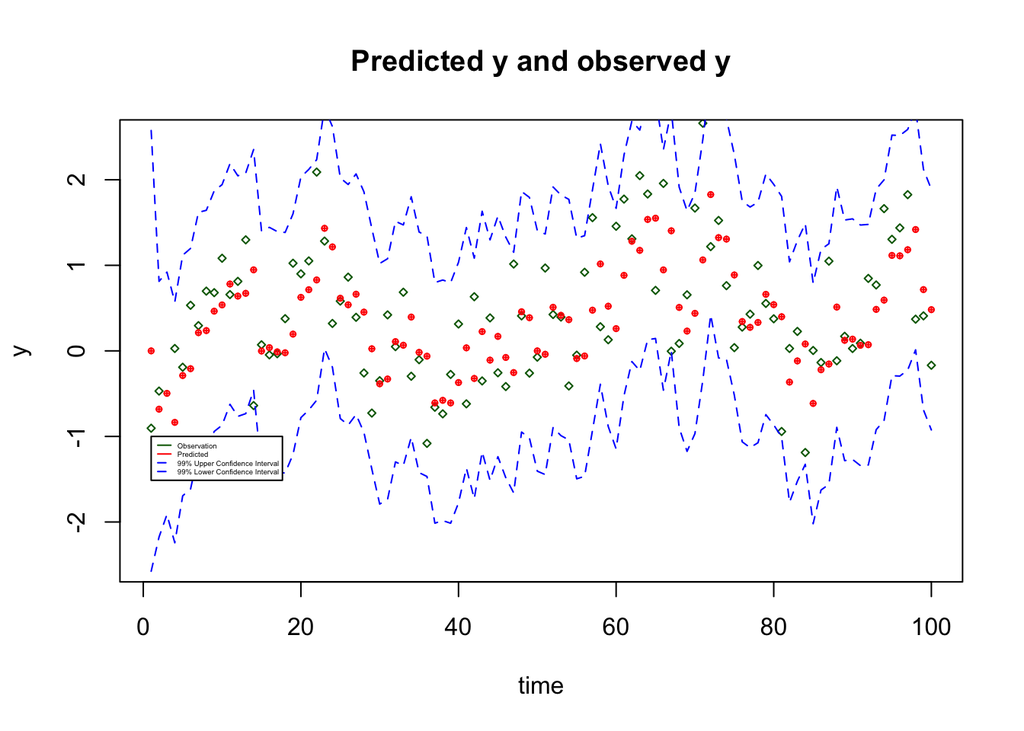

```r
set.seed(1)
gamma = 10
Sigmaw = 0.2
phi = exp(-1/gamma)
Sigmav = 1-exp(-2/gamma)
T <- 100
simulation <- kalmanSimulate(T=100,phi=phi,Sigmav=Sigmav,Sigmaw=Sigmaw)
y <- simulation$y
results <- kf.gp(y=y,gamma=gamma,Sigmaw=Sigmaw)

mu.p <- results$mu.p
Sigma.p <- results$Sigma.p

se.p <- sqrt(Sigma.p)

alpha=0.01
cv99 = qnorm(1-alpha/2)
CIupper.p <- mu.p + cv99*se.p
CIlower.p <- mu.p - cv99*se.p

plot(time,y,cex=0.5,col='darkgreen',pch=5,ylim=c(-2.5,2.5),main='Predicted y and observed y')
points(time,mu.p,cex=0.5,col='red',pch=10)
points(time,CIupper.p,col='blue',type ='l',lty=2,lwd=1)
points(time,CIlower.p,col='blue',type ='l',lty=2,lwd=1)
legend(1,-1,legend= c('Observation','Predicted','99% Upper Confidence Interval','99% Lower Confidence Interval'), col=c('darkgreen','red','blue','blue'),lty=c(1,1,2,2),cex=.3)
```

We see the KF fits indeed quite well. We further plot the smoothing distributions:

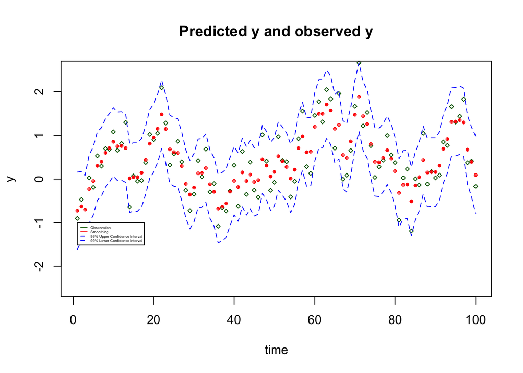

```r
mu.s <- results$mu.s
Sigma.s <- results$Sigma.s

se.s <- sqrt(Sigma.s)

alpha=0.01
cv99 = qnorm(1-alpha/2)
CIupper.s<- mu.s + cv99*se.s
CIlower.s <- mu.s - cv99*se.s

plot(time,y,cex=0.5,col='darkgreen',pch=5,ylim=c(-2.5,2.5),main='Predicted y and observed y')
points(time,mu.s,cex=0.5,col='red',pch=10)
points(time,CIupper.s,col='blue',type ='l',lty=2,lwd=1)
points(time,CIlower.s,col='blue',type ='l',lty=2,lwd=1)
legend(1,-1,legend= c('Observation','Smoothing','99% Upper Confidence Interval','99% Lower Confidence Interval'), col=c('darkgreen','red','blue','blue'),lty=c(1,1,2,2),cex=.3)
```

This indeed has narrower confidence interval and smoother trend. All observed values are all contained in the confidence interval.

## Hyper parameter Selection

In real life we never observe the hyper parameters $\gamma$ and $\sigma_w^2$. We propose two ways for hyper parameter selection: $\bullet$ Use `optim` to optimize against $\sigma_w^2$ and $\gamma$ against the loglikehood computed using `kf.loglikelihood`.

$\bullet$ Set the partial derivatives of the loglikelihood with respect to hyper parameters to 0. We will explain that in details later.

### Optimize over Loglikelihood

```r
kf.loglikelihood <- function(y,gamma,Sigmaw,m0=0,Sigma0=1){
  o <- kf.gp(y=y,gamma=gamma,Sigmaw=Sigmaw,m0=m0,Sigma0=Sigma0)
  mu.p <- o$mu.p
  Sigma.p <- o$Sigma.p
  result <- kf.loglikelihood1(y=y,mu.p=mu.p,Sigma.p=Sigma.p,Sigmaw=Sigmaw,m0=m0,Sigma0=Sigma0)
  return (result)
}

optim_parm <- function(y, m0=0, Sigma0=1){
  opt_param <- optim(par = c(5,0.5),
                     fn = function(parm) -1*kf.loglikelihood(y,parm[1],  parm[2], m0, Sigma0))
  return(list(gamma = opt_param$par[1],
              Sigmaw=opt_param$par[2]))
}
```

We fit the first $80\%$ of data to get an MLE estimates:

```r
mle <- optim_parm(y[1:80])
mle$gamma
```

```
## [1] 5.810705
```

```r
mle$Sigmaw
```

```
## [1] 0.1813112
```

Now we check if the MLE estimates is reasonable by making predictions on the whole data set $1:100$:

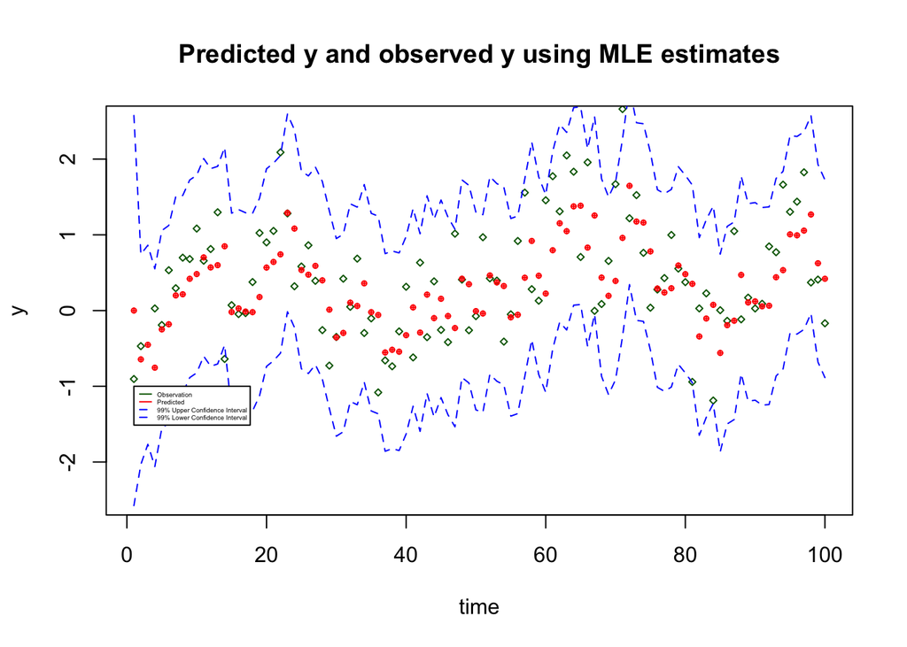

```r
results <- kf.gp(y=y,gamma=mle$gamma,Sigmaw=mle$Sigmaw)

mu.p <- results$mu.p
Sigma.p <- results$Sigma.p

se.p <- sqrt(Sigma.p)

alpha=0.01
cv99 = qnorm(1-alpha/2)
CIupper.p <- mu.p + cv99*se.p
CIlower.p <- mu.p - cv99*se.p

plot(time,y,cex=0.5,col='darkgreen',pch=5,ylim=c(-2.5,2.5),main='Predicted y and observed y using MLE estimates')
points(time,mu.p,cex=0.5,col='red',pch=10)
points(time,CIupper.p,col='blue',type ='l',lty=2,lwd=1)
points(time,CIlower.p,col='blue',type ='l',lty=2,lwd=1)
legend(1,-1,legend= c('Observation','Predicted','99% Upper Confidence Interval','99% Lower Confidence Interval'), col=c('darkgreen','red','blue','blue'),lty=c(1,1,2,2),cex=.3)
```

It’s still doing quite well.

The second method, more like a justification to our `optim`, is to compute the partial derivatives recursively and set that values to 0. The details of derivation are included in the project report, we give the final result here that how we can recursively update $\frac{\partial m_{t|t}}{\partial \theta}$ and $\frac{\partial \sigma^2_{t|t}}{\partial \theta}$ given $\frac{\partial m_{t|t-1}}{\partial \theta}$ and $\frac{\partial \sigma^2_{t|t-1}}{\partial \theta}$. And similarly update $\frac{\partial m_{t+1|t}}{\partial \theta}$ and $\frac{\partial \sigma^2_{t+1|t}}{\partial \theta}$ given $\frac{\partial m_{t|t}}{\partial \theta}$ and $\frac{\partial \sigma^2_{t|t}}{\partial \theta}$, where $\theta$ are hyper parameters.

$$\frac{\partial m_{t|t}}{\partial
\gamma}=\frac{\partial m_{t|t-1}}{\partial
\gamma}\frac{\sigma_w^2}{\sigma_w^2 + \sigma_{t|t-1}^2} +
(y_t-m_{t|t-1})\frac{\partial \sigma_{t|t-1}^2}{\partial
\gamma}\frac{\sigma_w^2}{(\sigma_w^2 + \sigma_{t|t-1}^2)^2}$$
$$\frac{\partial \sigma_{t|t}^2}{\partial
\gamma}= \frac{\sigma_w^4}{(\sigma_w^2 +
\sigma_{t|t-1}^2)^2}\frac{\partial \sigma_{t|t-1}^2}{\partial
\gamma}$$
$$\frac{\partial
m_{t|t}}{\partial \sigma_w^2}=frac{\partial m_{t|t-1}}{\partial
\sigma_w^2} \frac{\sigma_w^2}{\sigma_w^2 + \sigma_{t|t-1}^2} +
(y_t-m_{t|t-1})\frac{\frac{\partial \sigma_{t|t-1}^2}{\partial
\sigma_w^2}\sigma_w^2-\sigma_{t|t-1}^2}{(\sigma_w^2+\sigma_{t|t-1}^2)^2}$$
$$\frac{\partial \sigma_{t|t}^2}{\partial
\sigma_w^2}=\sigma_w^4\frac{\partial \sigma_{t|t-1}^2}{\partial
\sigma_w^2}\frac{1}{(\sigma_w^2+\sigma_{t|t-1}^2)^2} +
\sigma_{t|t-1}^4\frac{1}{(\sigma_w^2+\sigma_{t|t-1}^2)^2}$$
$$\frac{\partial m_{t+1|t}}{\partial \gamma} =
\frac{1}{\gamma^2}\exp(-\frac{1}{\gamma})m_{t|t} +
\exp(-\frac{1}{\gamma})\frac{\partial m_{t|t}}{\partial \gamma}$$
$$\frac{\partial \sigma_{t+1|t}^2}{\partial
\gamma} = -\frac{2}{\gamma^2}\exp(-\frac{2}{\gamma}) +
\exp(-\frac{2}{\gamma})\frac{\partial \sigma_{t|t}^2}{\partial \gamma} +
\frac{2}{\gamma^2}\exp(-\frac{2}{\gamma})\sigma_{t|t}^2$$
$$\frac{\partial m_{t+1|t}}{\partial \sigma_w^2} =
\exp(-\frac{1}{\gamma})\frac{\partial m_{t|t}}{\partial
\sigma_w^2}$$
$$\frac{\partial
\sigma_{t+1|t}^2}{\partial \sigma_w^2} =
\exp(-\frac{2}{\gamma})\frac{\partial \sigma^2_{t|t}}{\partial
\sigma_w^2}$$
Finally given all these results we have the partial derivatives with respect to the log likelihood:
$$\frac{\partial \log(p(y_{k+1}|y_{1:k}))}{\partial
\gamma} =
\frac{y_{k+1}-m_{k+1|k}}{\sigma_{k+1|k}^2+\sigma_w^2}\frac{\partial
m_{k+1|k}}{\partial \gamma}
-\left(\frac{1}{2(\sigma_{k+1|k}^2+\sigma_w^2)}-\frac{(y_{k+1}-m_{k+1|k})^2}{2(\sigma_{k+1|k}^2+\sigma_w^2)^2}\right)\frac{\partial
\sigma_{k+1|k}^2}{\partial \gamma}$$
and
$$\frac{\partial \log(p(y_{k+1}|y_{1:k}))}{\partial
\sigma_w^2} =
\frac{y_{k+1}-m_{k+1|k}}{\sigma_{k+1|k}^2+\sigma_w^2}\frac{\partial
m_{k+1|k}}{\partial \sigma_w^2} -\frac{1+\frac{\partial
\sigma_{k+1|k}^2}{\partial
\sigma_w^2}}{2(\sigma_{k+1|k}^2+\sigma_w^2)}+\frac{(y_{k+1}-m_{k+1|k})^2}{2(\sigma_{k+1|k}^2+\sigma_w^2)^2}(1+\frac{\partial
\sigma_{k+1|k}^2}{\partial \sigma_w^2})$$
.

```r
partialDerivatives <- function(y,gamma,Sigmaw,m0=0,Sigma0=1){
  T <- length(y)
  o <- kf.gp(y=y,gamma=gamma,Sigmaw=Sigmaw,m0=m0,Sigma0=Sigma0)
  mu.p <- o$mu.p
  Sigma.p <- o$Sigma.p
  mu.f <- o$mu.f
  Sigma.f <- o$Sigma.f
  partial.f.mg <- rep(NA,T)
  partial.f.sg <- rep(NA,T)
  partial.f.ms <- rep(NA,T)
  partial.f.ss <- rep(NA,T)
  partial.p.mg <- rep(NA,T)
  partial.p.sg <- rep(NA,T)
  partial.p.ms <- rep(NA,T)
  partial.p.ss <- rep(NA,T)
  partial.y.g <- rep(NA,T)
  partial.y.s <- rep(NA,T)

  #time 1
  partial.f.mg[1] <- 0
  partial.f.sg[1] <- 0
  partial.p.ms[1] <- 0
  partial.p.ss[1] <- 0
  partial.p.mg[1] <- 0
  partial.p.sg[1] <- 0
  partial.f.ms[1] <- -Sigma0/((Sigma0+Sigmaw)^2)*(y[1]-m0)
  partial.f.ss[1] <- Sigma0^2/((Sigma0+Sigmaw)^2)
  partial.y.g[1] <- 0
  partial.y.s[1] <- 1/(2*(Sigma0+Sigmaw))*((y[1]-m0)^2/(Sigma0+Sigmaw)-1)

  #time 2:T
  for (t in 2:T){

    #prediction
    partial.p.mg[t] <- 1/(gamma^2)*exp(-1/gamma)*mu.f[t-1] + exp(-1/gamma)*partial.f.mg[t-1]
    partial.p.sg[t] <- -2/(gamma^2)*exp(-2/gamma) + exp(-2/gamma)*partial.f.sg[t-1] + 2/(gamma^2)*exp(-2/gamma)*Sigma.f[t-1]
    partial.p.ms[t] <- exp(-1/gamma)*partial.f.ms[t-1]
    partial.p.ss[t] <- exp(-2/gamma)*partial.f.ss[t-1]

    #update
    partial.f.mg[t]<- partial.p.mg[t]*Sigmaw/(Sigmaw+Sigma.p[t]) + (y[t]-mu.p[t])*partial.p.sg[t]*Sigmaw/((Sigmaw+Sigma.p[t])^2)
    partial.f.sg[t]<- Sigmaw^2/((Sigmaw+Sigma.p[t])^2) * partial.p.sg[t]
    partial.f.ms[t]<- partial.p.ms[t]*Sigmaw/(Sigmaw+Sigma.p[t]) + (y[t]-mu.p[t])*(partial.p.ss[t]*Sigmaw-Sigma.p[t])/((Sigmaw+Sigma.p[t])^2)
    partial.f.ss[t]<- Sigmaw^2*partial.p.ss[t]/((Sigmaw+Sigma.p[t])^2) + Sigma.p[t]^2/((Sigmaw+Sigma.p[t])^2)

    #get the derivatives with respect to log p(y)
    denom <- Sigmaw + Sigma.p[t]
    partial.y.g[t] <- (y[t]-mu.p[t])/denom*partial.p.mg[t] -(1/(2*denom)-(y[t]-mu.p[t])^2/(2*denom^2))*partial.p.sg[t]
    partial.y.s[t] <- (y[t]-mu.p[t])/denom*partial.p.ms[t] - (1/(2*denom)-(y[t]-mu.p[t])^2/(2*denom^2))*(1+partial.p.ss[t])
  }
  partial.g <- sum(partial.y.g)
  partial.s <- sum(partial.y.s)
  return (list(partial.g=partial.g,partial.s = partial.s))
}
```

We check if the MLE estimates in approach 1 has small partial derivatives:

```r
partialDerivatives(y[1:80],mle$gamma,mle$Sigmaw)
```

```
## $partial.g
## [1] 0.02292685
##
## $partial.s
## [1] 0.5588343
```

We will use the `optim` for our method as the naive implementation of the partial derivatives recursion is slower compared to built-in `optim`, and it is not quite correct.

# Read Data Analysis

https://machinelearningmastery.com/time-series-data-stationary-python/

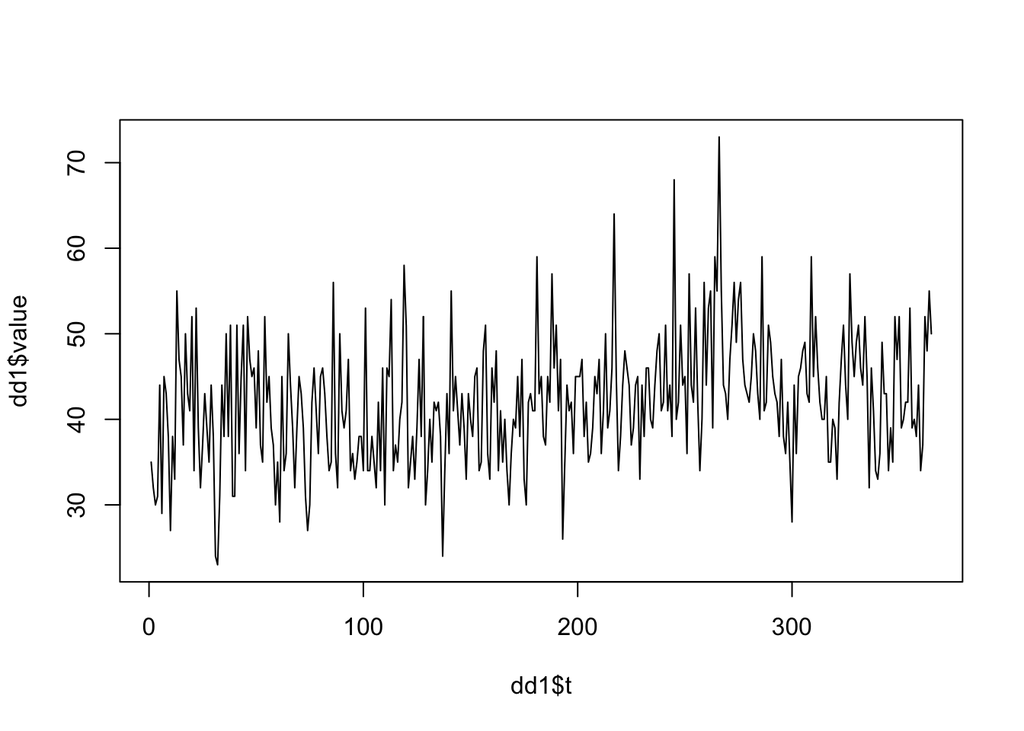

```r
read.file <- read.csv("code/female_birth.csv") %>% data.table()
dd1 <- read.file %>% select("Births") %>% mutate(t=1:nrow(read.file))
colnames(dd1)[1] <- "value"

# plot the time series
plot(dd1$t, dd1$value, lty=1, type ='l')
```

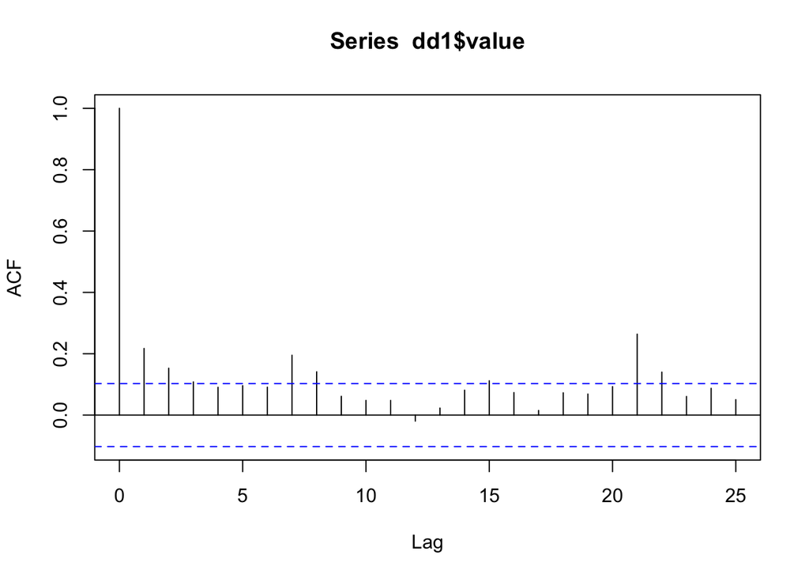

```r
# check stationarity
acf(dd1$value)
```

```r
# hyper-parameter selecton

mle <- optim_parm(dd1$value[1:as.integer(nrow(dd1)*0.8)])
mle$gamma
```

```
## [1] 167.8398
```

```r
mle$Sigmaw
```

```
## [1] 31.46572
```

[figure not shown]

```r
results <- kf.gp(y=dd1$value,gamma=mle$gamma,Sigmaw=mle$Sigmaw)

mu.p <- results$mu.p
Sigma.p <- results$Sigma.p

se.p <- sqrt(Sigma.p)

alpha=0.05
cv99 = qnorm(1-alpha/2)
CIupper.p <- mu.p + cv99*se.p
CIlower.p <- mu.p - cv99*se.p

plot(dd1$t,
     dd1$value,
     cex=0.5,col='darkgreen',
     pch=5,main='Predicted and observed female births in 1959')
points(dd1$t, mu.p, cex=0.5, col='red', pch=10)
points(dd1$t, CIupper.p, col='blue', type ='l', lty=2, lwd=1)
points(dd1$t, CIlower.p, col='blue', type ='l', lty=2, lwd=1)
legend("bottomleft",
       legend = c('Observation','Predicted',
                 '99% Upper Confidence Interval',
                 '99% Lower Confidence Interval'),
       col = c('darkgreen','red','blue','blue'),
       lty=c(1,1,2,2), cex=.3)
```

# Comparison of Performance between KF and Gaussian Process Regression

```r
state.space.gp.fit <- function(y, gamma, sigma.w, alpha){

  n <- length(y)
  # The K12 and K22 for k=n
  K12.n <- matrix(sapply(n:1, function(k)exp(-k/gamma)), nrow=1)
  K22.n <- matrix(0, n, n)
  for(i in 1:n){
    for(j in 1:n){
      K22.n [i,j] <- exp(-abs(i-j)/gamma)
    }
  }

  # fit data
  gp.record <- data.frame(t = NULL, mean = NULL, sd = NULL)

  # GP regression in online fashion
  for(k in 1:n){
    # y_{1:k}
    y.k <- matrix(y[1:k], ncol=1)
    # corresponding K12 and K22
    K12.k <- matrix(K12.n[, (n-k+1):n], nrow=1)
    K22.k <- K22.n[1:k, 1:k]

    # inverse of (K22 + sigma^2*I)
    solve.inv <- solve(K22.k + sigma.w^2*identity(k))

    # estimated mean and sd^2 for y_{k+1}
    pred.mu <- K12.k %*% solve.inv %*% y.k
    pred.K <- 1- K12.k %*%  solve.inv %*% t(K12.k)

    # record the result
    gp.record <- rbind(gp.record,
                     data.frame(t = k,
                                mean = as.numeric(pred.mu),
                                sd = as.numeric(sqrt(pred.K))))
  }

  # (1-alpha)% credible interval
  gp.record$upper <- qnorm(1-alpha/2, mean=gp.record$mean, sd=gp.record$sd )
  gp.record$lower <- qnorm(alpha/2, mean=gp.record$mean, sd=gp.record$sd)

  return( gp.record)
}
```

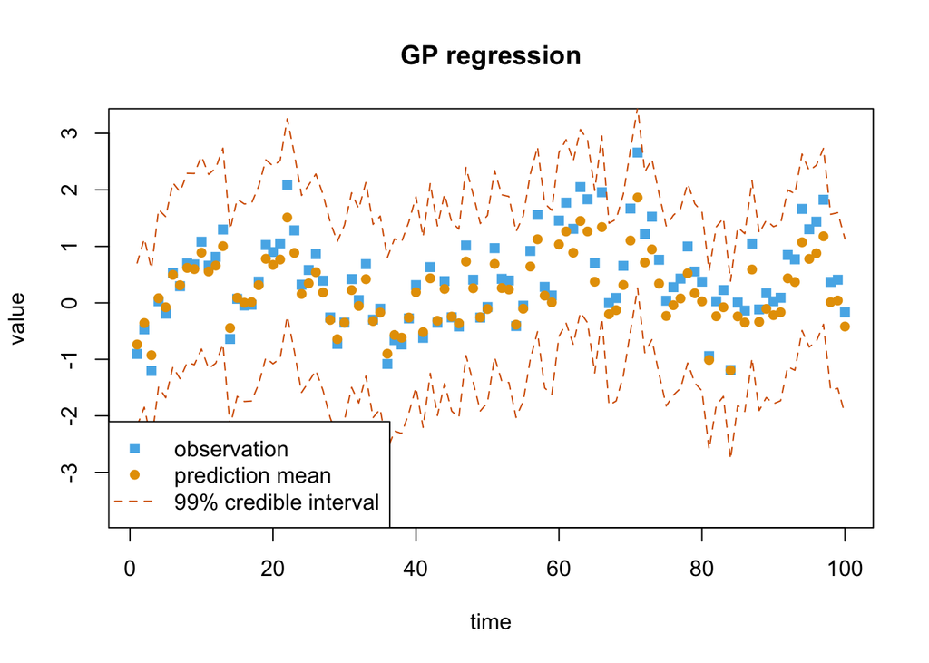

```r
# fitting GP regression with 99% credible interval
alpha <- 0.01

mle <- optim_parm(y[1:80])
gamma <-  mle$gamma
sigma.w <- mle$Sigmaw
gp.record <- state.space.gp.fit(y, mle$gamma, mle$Sigmaw, alpha)

plot(1:length(y), y, col="#56B4E9", pch=15, ylim=c(min(y)-2.5, max(y)+0.5),
       main = "GP regression", xlab="time", ylab="value")
points(gp.record$t, gp.record$mean, col="#E69F00", pch=16)
lines(gp.record$t, gp.record$upper, col="#D55E00", lty=2)
lines(gp.record$t, gp.record$lower, col="#D55E00", lty=2)
legend("bottomleft", legend = c("observation", "prediction mean",
                                "99% credible interval"),
       pch = c(15, 16, NA),
       lty = c(NA, NA, 2),
       col=c("#56B4E9","#E69F00","#D55E00"))
```

# Using Rcpp

```r
library(Rcpp)
sourceCpp(code='
#include <Rcpp.h>
using namespace Rcpp;

// Rcpp version of the function
// The function takes NumericVector y, double phi, double Sigmav, double Sigmaw, double m0, and double Sigma0 as input
// It returns a list containing the calculated values
List kalmanRcpp(NumericVector y, double phi, double Sigmav, double Sigmaw, double m0, double Sigma0) {
  int T = y.size();

  // Initialization
  NumericVector mu_p(T);
  NumericVector Sigma_p(T);
  NumericVector mu_f(T);
  NumericVector Sigma_f(T);
  NumericVector mu_s(T);
  NumericVector Sigma_s(T);

  // Forward recursion time 1
  mu_p[0] = m0;
  Sigma_p[0] = Sigma0;
  mu_f[0] = m0 + (y[0] - m0) * (Sigma0 / (Sigma0 + Sigmaw));
  Sigma_f[0] = Sigma0 - pow(Sigma0, 2) / (Sigma0 + Sigmaw);

  // Forward recursion time 2:T
  for (int t = 1; t < T; t++) {
    // Prediction
    mu_p[t] = phi * mu_f[t - 1];
    Sigma_p[t] = pow(phi, 2) * Sigma_f[t - 1] + Sigmaw;

    // Update
    double deno = Sigmaw + Sigma_p[t];
    mu_f[t] = (Sigmaw * mu_p[t]) / deno + (Sigma_p[t] * y[t]) / deno;
    Sigma_f[t] = (Sigmaw * Sigma_p[t]) / deno;
  }

  // Backward recursion
  mu_s[T - 1] = mu_f[T - 1];
  Sigma_s[T - 1] = Sigma_f[T - 1];
  for (int t = T - 2; t >= 0; t--) {
    double J = phi * Sigma_f[t] / Sigma_p[t + 1];
    mu_s[t] = mu_f[t] + J * (mu_s[t + 1] - mu_p[t + 1]);
    Sigma_s[t] = Sigma_f[t] + pow(J, 2) * (Sigma_s[t + 1] - Sigma_p[t + 1]);
  }

  // Create and return the list
  List result = List::create(
    Named("mu.f") = mu_f,
    Named("Sigma.f") = Sigma_f,
    Named("mu.p") = mu_p,
    Named("Sigma.p") = Sigma_p,
    Named("mu.s") = mu_s,
    Named("Sigma.s") = Sigma_s
  );

  return result;
}

// Rcpp module to expose the function to R
RCPP_MODULE(kalmanModule) {
  function("kalmanRcpp", &kalmanRcpp);
}

')
```

```r
microbenchmark(R = kalman(y, phi=1,
                          Sigmav=0.02, Sigmaw=0.2,
                          m0=0, Sigma0=1),
               Rcpp = kalmanRcpp(y, phi=1,
                                 Sigmav=0.02, Sigmaw=0.2,
                                 m0=0, Sigma0=1)) %>%
pander()
```

Unit: microseconds

| expr | min | lq | mean | median | uq | max | neval |
| --- | --- | --- | --- | --- | --- | --- | --- |
| R | 35.79 | 36.12 | 37.24 | 37.15 | 37.47 | 49 | 100 |
| Rcpp | 2.911 | 3.034 | 3.581 | 3.116 | 4.162 | 13.73 | 100 |